# BIOL90042 Final Project: PRS and Gait

Author

Ratnpriya

# Bringing the datasets together

## Is there any relationship between the PRS and gait of patients in the clinical trial?

To answer this question, we need information from two different arms of the study: the polygenic risk score (PRS) from the population genetics data (`prs.Rda`), and the gait data from the clinical trial (`gait.Rda`). Participants are identified by a unique `donorid`, so we can use this column to connect the two datasets. Only participants who appear in both datasets can be used.

## Setup

```r
# Load the tidyverse packages
library(tidyverse)

# Load the population genetics data and the clinical trial data
# (both files sit in the same folder as this document)
load("prs.Rda")
load("gait.Rda")
```

## Step 1: Calculate the PRS for each participant

We calculate the PRS in the same way as in the population genetics section: reshape the genotypes into long format, join the GWAS effect sizes (beta) for each locus, multiply dosage by beta, and add up the 15 locus scores for each donor.

```r
# Reshape the genotypes so that each row is one donor at one locus
genotypes_long <- ca_co_genotypes %>%
  pivot_longer(
    cols = -c(donorid, status),
    names_to = "locus",
    values_to = "dosage"
  )

# Add the GWAS effect size (beta) for each locus, and calculate the score for each locus
prs_data <- genotypes_long %>%
  left_join(gwas_top_hits, by = "locus") %>%
  mutate(
    locus_score = dosage * beta # dosage x beta for each locus
  )

# Add the 15 locus scores together to get one PRS per donor
participant_prs <- prs_data %>%
  summarise(
    PRS = sum(locus_score),
    .by = c(donorid, status)
  )

head(participant_prs)
```

```
# A tibble: 6 × 3
  donorid status   PRS
  <chr>   <chr>  <dbl>
1 d001    case   0.315
2 d002    ctrl   0.969
3 d003    ctrl   0.651
4 d004    ctrl   1.16
5 d005    ctrl   0.7
6 d006    ctrl   0.994
```

## Step 2: Calculate the gait score for each participant

We calculate the gait score in the same way as in the clinical trial section: the standard deviation of each participant’s orientation over the 700 seconds. A larger gait score means a less smooth gait and poorer balance.

```r
# Reshape the gait data so that each row is one donor at one second
gait_long <- gait_data %>%
  pivot_longer(
    cols = ends_with("_secs"),
    names_to = "time",
    values_to = "orientation"
  )

# Calculate the gait score (standard deviation of orientation) for each participant
participant_gait <- gait_long %>%
  summarise(
    gait_score = sd(orientation),
    .by = c(donorid, treatment, age, exercise)
  )

head(participant_gait)
```

```
# A tibble: 6 × 5
  donorid treatment        age exercise gait_score
  <chr>   <chr>          <dbl> <chr>         <dbl>
1 d001    New compound    67.8 n              8.33
2 d032    New compound    64.5 n              6.49
3 d069    New compound    69.8 y              6.89
4 d072    L-DOPA control  77.2 y             10.2
5 d104    New compound    82.8 n             12.0
6 d154    L-DOPA control  67.6 y              7.31
```

## Step 3: Join the two datasets using donorid

Before joining, we check how many of the 16 clinical trial participants also appear in the PRS data.

```r
# Which clinical trial participants are missing from the PRS data? (should be none if all 16 overlap)
participant_gait %>%
  anti_join(participant_prs, by = "donorid")
```

```
# A tibble: 0 × 5
# ℹ 5 variables: donorid <chr>, treatment <chr>, age <dbl>, exercise <chr>,
#   gait_score <dbl>
```

```r
# Keep only participants who appear in both datasets
gait_prs <- participant_gait %>%
  inner_join(participant_prs, by = "donorid")

nrow(gait_prs) # number of participants with both a PRS and a gait score
```

```
[1] 16
```

```r
# Check the case/control status of these participants
gait_prs %>%
  count(status)
```

```
# A tibble: 1 × 2
  status     n
  <chr>  <int>
1 case      16
```

All 16 clinical trial participants were also present in the population genetics dataset, so all 16 could be used in this analysis. All 16 were classified as cases, which is consistent with the clinical trial only including patients with PD.

## Step 4: Look at the relationship

We start with a scatterplot of PRS against gait score. We colour the points by treatment, because treatment was found to be related to gait in the clinical trial section.

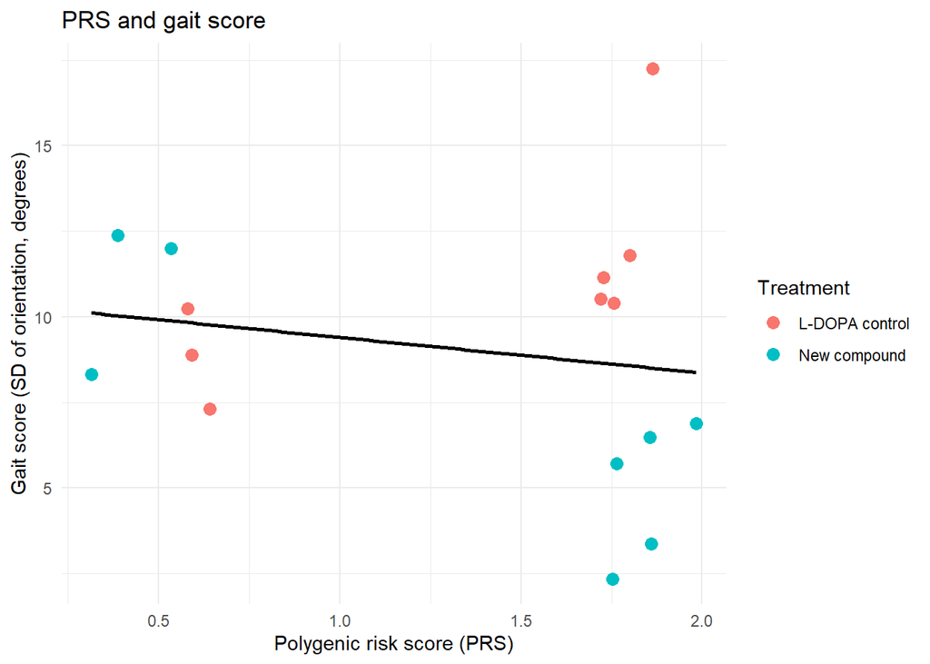

```r
# Scatterplot of PRS vs gait score
gait_prs %>%
  ggplot(aes(x = PRS, y = gait_score, colour = treatment)) +
  geom_point(size = 3) +
  geom_smooth(method = "lm", se = FALSE, aes(group = 1), colour = "black") + #overall trend line
  labs(
    x = "Polygenic risk score (PRS)",
    y = "Gait score (SD of orientation, degrees)",
    title = "PRS and gait score",
    colour = "Treatment"
  ) +
  theme_minimal()
```

**Description of the plot:**

The PRS values of the 16 participants fall into two separate groups: a lower-scoring group (PRS about 0.3 to 0.65) and a higher-scoring group (PRS about 1.7 to 2.0). The trend line has a slight downward slope, but gait scores vary widely within both PRS groups, so there is no clear relationship between PRS and gait score. In the higher-PRS group, participants receiving L-DOPA generally have higher gait scores than those receiving the new compound, which is consistent with the treatment effect seen in the clinical trial analysis and suggests that treatment explains more of the variation in gait than PRS does.

## Step 5: Test the relationship

We use a Pearson correlation to test whether there is a linear relationship between PRS and gait score. This assumes a roughly linear relationship (which we checked in the scatterplot) and approximately normal variables, so we check normality of both variables and also run a Spearman correlation, which is rank-based and does not assume normality.

```r
# Shapiro-Wilk tests for PRS and gait score (p > 0.05 = no evidence against normality)
shapiro.test(gait_prs$PRS)
```

```
    Shapiro-Wilk normality test

data:  gait_prs$PRS
W = 0.74756, p-value = 0.0005938
```

```r
shapiro.test(gait_prs$gait_score)
```

```
    Shapiro-Wilk normality test

data:  gait_prs$gait_score
W = 0.97214, p-value = 0.872
```

```r
# Pearson correlation between PRS and gait score
cor.test(gait_prs$PRS, gait_prs$gait_score)
```

```
    Pearson's product-moment correlation

data:  gait_prs$PRS and gait_prs$gait_score
t = -0.69721, df = 14, p-value = 0.4971
alternative hypothesis: true correlation is not equal to 0
95 percent confidence interval:
 -0.6223747  0.3437338
sample estimates:
       cor
-0.1831844
```

```r
# Spearman correlation: rank-based check that does not assume normality
cor.test(gait_prs$PRS, gait_prs$gait_score, method = "spearman")
```

```
    Spearman's rank correlation rho

data:  gait_prs$PRS and gait_prs$gait_score
S = 868, p-value = 0.2989
alternative hypothesis: true rho is not equal to 0
sample estimates:
       rho
-0.2764706
```

**Interpretation:**

The PRS values were not normally distributed (Shapiro-Wilk p < 0.001), with participants falling into a lower-scoring group and a higher-scoring group, whereas gait score was consistent with normality (p = 0.872). The Pearson correlation should therefore be interpreted cautiously, and the rank-based Spearman correlation is the more appropriate test. There was no significant relationship between PRS and gait score (Spearman rho = -0.28, p = 0.299; Pearson r = -0.18, 95% CI -0.62 to 0.34, p = 0.497). Both coefficients were weakly negative, but the confidence interval is wide and includes zero, so with only 16 participants we cannot rule out a modest relationship in either direction. A non-significant result does not show that no relationship exists.

## Step 6: Take treatment, age and exercise into account

In the clinical trial section, treatment, age and exercise were all related to gait. If the PRS is related to any of these, they could hide or create a relationship with gait. We first check that PRS is similar across treatment and exercise groups, and then fit a model that includes PRS together with these variables.

```r
# Mean PRS in each treatment group, and in each exercise group
gait_prs %>%
  summarise(n = n(), mean_PRS = mean(PRS), sd_PRS = sd(PRS), .by = treatment)
```

```
# A tibble: 2 × 4
  treatment          n mean_PRS sd_PRS
  <chr>          <int>    <dbl>  <dbl>
1 New compound       8     1.31  0.747
2 L-DOPA control     8     1.34  0.607
```

```r
gait_prs %>%
  summarise(n = n(), mean_PRS = mean(PRS), sd_PRS = sd(PRS), .by = exercise)
```

```
# A tibble: 2 × 4
  exercise     n mean_PRS sd_PRS
  <chr>    <int>    <dbl>  <dbl>
1 n            8     1.13  0.730
2 y            8     1.51  0.560
```

```r
# Correlation between PRS and age
cor.test(gait_prs$PRS, gait_prs$age)
```

```
    Pearson's product-moment correlation

data:  gait_prs$PRS and gait_prs$age
t = -0.74016, df = 14, p-value = 0.4714
alternative hypothesis: true correlation is not equal to 0
95 percent confidence interval:
 -0.6292326  0.3337546
sample estimates:
       cor
-0.1940561
```

```r
# Spearman correlation between PRS and age (PRS is not normal, so this rank-based check is safer)
cor.test(gait_prs$PRS, gait_prs$age, method = "spearman")
```

```
    Spearman's rank correlation rho

data:  gait_prs$PRS and gait_prs$age
S = 814, p-value = 0.4632
alternative hypothesis: true rho is not equal to 0
sample estimates:
       rho
-0.1970588
```

Mean PRS was almost identical in the two treatment groups (1.31 for the new compound and 1.34 for L-DOPA) and was not significantly correlated with age (r = -0.19, 95% CI -0.63 to 0.33, p = 0.471). A Spearman correlation, which does not assume normality, gave the same conclusion (rho = -0.20, p= 0.463). Mean PRS was somewhat higher in participants who did the exercise routine (1.51) than in those who did not (1.13), although both groups showed a wide spread of PRS values. PRS therefore does not appear to be strongly related to treatment or age.

```r
# Model with PRS only
prs_only_model <- lm(gait_score ~ PRS, data = gait_prs)
summary(prs_only_model)
```

```
Call:
lm(formula = gait_score ~ PRS, data = gait_prs)

Residuals:
    Min      1Q  Median      3Q     Max
-6.2725 -2.1328 -0.2679  2.1757  8.7560

Coefficients:
            Estimate Std. Error t value Pr(>|t|)
(Intercept)   10.436      2.180   4.786  0.00029 ***
PRS           -1.037      1.487  -0.697  0.49709
---
Signif. codes:  0 '***' 0.001 '**' 0.01 '*' 0.05 '.' 0.1 ' ' 1

Residual standard error: 3.787 on 14 degrees of freedom
Multiple R-squared:  0.03356,   Adjusted R-squared:  -0.03548
F-statistic: 0.4861 on 1 and 14 DF,  p-value: 0.4971
```

```r
# Model with PRS, adjusted for treatment, age and exercise
prs_adjusted_model <- lm(gait_score ~ PRS + treatment + age + exercise, data = gait_prs)
summary(prs_adjusted_model)
```

```
Call:
lm(formula = gait_score ~ PRS + treatment + age + exercise, data = gait_prs)

Residuals:
     Min       1Q   Median       3Q      Max
-1.53875 -0.75549  0.05087  0.58356  1.74813

Coefficients:
                       Estimate Std. Error t value Pr(>|t|)
(Intercept)           -10.00130    3.18677  -3.138 0.009436 **
PRS                     0.43391    0.48219   0.900 0.387465
treatmentNew compound  -3.26431    0.58125  -5.616 0.000157 ***
age                     0.30439    0.04074   7.472 1.24e-05 ***
exercisey              -3.70614    0.60416  -6.134 7.37e-05 ***
---
Signif. codes:  0 '***' 0.001 '**' 0.01 '*' 0.05 '.' 0.1 ' ' 1

Residual standard error: 1.155 on 11 degrees of freedom
Multiple R-squared:  0.9294,    Adjusted R-squared:  0.9037
F-statistic: 36.21 on 4 and 11 DF,  p-value: 2.846e-06
```

Since this is a linear model, we check its assumptions using the residuals.

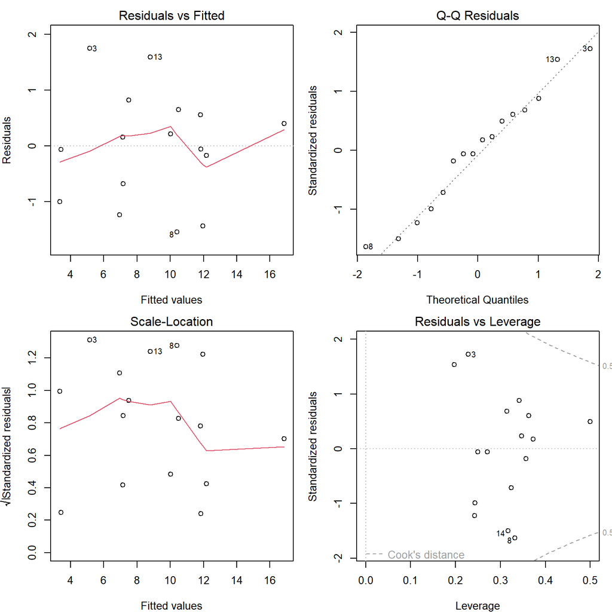

```r
par(mfrow = c(2, 2), mar = c(4, 4, 2, 1)) # show the 4 diagnostic plots together
plot(prs_adjusted_model)
```

```r
par(mfrow = c(1, 1)) # reset
```

```r
# Shapiro-Wilk test on the model residuals (p > 0.05 = no evidence against normality)
shapiro.test(residuals(prs_adjusted_model))
```

```
    Shapiro-Wilk normality test

data:  residuals(prs_adjusted_model)
W = 0.95988, p-value = 0.6595
```

**Interpretation & Final conclusion:**

In a model with PRS alone, PRS was not significantly associated with gait score (coefficient -1.04, p = 0.497), and it explained very little of the variation in gait (R^2 = 0.03). After adjusting for treatment, age and exercise, the PRS coefficient was +0.43 (p = 0.387), which was still not significant and was in the opposite direction, suggesting there is no consistent relationship. In this adjusted model, the new compound (-3.26, p < 0.001), exercise (-3.71, p < 0.001) and older age (+0.30 per year, p < 0.001) were all significantly associated with gait score, as in the clinical trial analysis, and together the variables explained most of the variation in gait (R^2 = 0.93). The residual plots showed no clear pattern, no participant had a large influence on the model, and the Shapiro-Wilk test on the residuals gave no evidence against normality (p = 0.660), so the model assumptions appear reasonable. Overall, we found no evidence that the PRS is related to gait in these patients. However, with only 16 participants we had little power to detect a modest relationship, and the PRS was built from 15 loci chosen for PD risk and not for motor symptoms, so these results do not show that genetic risk has no influence on gait.

**Limitations:**

- The sample is small (at most 16 participants), so the analysis has little power to detect a relationship, and the estimates are imprecise.
- The PRS values of these 16 participants form two separate clusters, with none in the middle, so we cannot tell how gait changes across intermediate PRS values.
- The PRS was built from 15 loci that were chosen because they are associated with PD risk. They were not chosen to predict gait severity, so the score may not be expected to capture motor symptoms.
- This analysis shows an association (or the lack of one) in this dataset, and does not show that genetic risk causes differences in gait.